# Risk Factor Analysis

## Outcome Variable

**Outcome Variable:** ever_stunted

## Predictor Variables

**Intervention Variable:** parity

**Adjustment Set:**

- arm
- W_mage
- meducyrs
- feducyrs
- hhwealth_quart
- W_mhtcm
- W_mwtkg
- W_mbmi
- vagbrth
- W_nrooms
- impsan
- delta_W_mage
- delta_meducyrs
- delta_feducyrs
- delta_hhwealth_quart
- delta_W_mhtcm
- delta_W_mwtkg
- delta_W_mbmi
- delta_vagbrth
- delta_W_nrooms
- delta_impsan

## Stratifying Variables

The analysis was stratified on these variable(s):

- agecat
- studyid
- country

## Data Summary

| agecat | studyid | country | parity | ever_stunted | n_cell | n |
| --- | --- | --- | --- | --- | --- | --- |
| 0-24 months | COHORTS | GUATEMALA | 1 | 0 | 54 | 1360 |
| 0-24 months | COHORTS | GUATEMALA | 1 | 1 | 159 | 1360 |
| 0-24 months | COHORTS | GUATEMALA | 2 | 0 | 44 | 1360 |
| 0-24 months | COHORTS | GUATEMALA | 2 | 1 | 148 | 1360 |
| 0-24 months | COHORTS | GUATEMALA | 3+ | 0 | 223 | 1360 |
| 0-24 months | COHORTS | GUATEMALA | 3+ | 1 | 732 | 1360 |
| 0-24 months | COHORTS | INDIA | 1 | 0 | 511 | 4630 |
| 0-24 months | COHORTS | INDIA | 1 | 1 | 301 | 4630 |
| 0-24 months | COHORTS | INDIA | 2 | 0 | 797 | 4630 |
| 0-24 months | COHORTS | INDIA | 2 | 1 | 388 | 4630 |
| 0-24 months | COHORTS | INDIA | 3+ | 0 | 1511 | 4630 |
| 0-24 months | COHORTS | INDIA | 3+ | 1 | 1122 | 4630 |
| 0-24 months | COHORTS | PHILIPPINES | 1 | 0 | 269 | 3058 |
| 0-24 months | COHORTS | PHILIPPINES | 1 | 1 | 409 | 3058 |
| 0-24 months | COHORTS | PHILIPPINES | 2 | 0 | 242 | 3058 |
| 0-24 months | COHORTS | PHILIPPINES | 2 | 1 | 448 | 3058 |
| 0-24 months | COHORTS | PHILIPPINES | 3+ | 0 | 448 | 3058 |
| 0-24 months | COHORTS | PHILIPPINES | 3+ | 1 | 1242 | 3058 |
| 0-24 months | GMS-Nepal | NEPAL | 1 | 0 | 74 | 698 |
| 0-24 months | GMS-Nepal | NEPAL | 1 | 1 | 137 | 698 |
| 0-24 months | GMS-Nepal | NEPAL | 2 | 0 | 74 | 698 |
| 0-24 months | GMS-Nepal | NEPAL | 2 | 1 | 107 | 698 |
| 0-24 months | GMS-Nepal | NEPAL | 3+ | 0 | 104 | 698 |
| 0-24 months | GMS-Nepal | NEPAL | 3+ | 1 | 202 | 698 |
| 0-24 months | JiVitA-3 | BANGLADESH | 1 | 0 | 4760 | 27227 |
| 0-24 months | JiVitA-3 | BANGLADESH | 1 | 1 | 5492 | 27227 |
| 0-24 months | JiVitA-3 | BANGLADESH | 2 | 0 | 4853 | 27227 |
| 0-24 months | JiVitA-3 | BANGLADESH | 2 | 1 | 4146 | 27227 |
| 0-24 months | JiVitA-3 | BANGLADESH | 3+ | 0 | 4128 | 27227 |
| 0-24 months | JiVitA-3 | BANGLADESH | 3+ | 1 | 3848 | 27227 |

[output cut: 168 more lines]

The following strata were considered:

- agecat: 0-24 months, studyid: COHORTS, country: GUATEMALA
- agecat: 0-24 months, studyid: COHORTS, country: INDIA
- agecat: 0-24 months, studyid: COHORTS, country: PHILIPPINES
- agecat: 0-24 months, studyid: GMS-Nepal, country: NEPAL
- agecat: 0-24 months, studyid: JiVitA-3, country: BANGLADESH
- agecat: 0-24 months, studyid: Keneba, country: GAMBIA
- agecat: 0-24 months, studyid: PROVIDE, country: BANGLADESH
- agecat: 0-24 months, studyid: SAS-CompFeed, country: INDIA
- agecat: 0-24 months, studyid: SAS-FoodSuppl, country: INDIA
- agecat: 0-24 months, studyid: TanzaniaChild2, country: TANZANIA, UNITED REPUBLIC OF
- agecat: 0-24 months, studyid: ZVITAMBO, country: ZIMBABWE
- agecat: 0-6 months, studyid: COHORTS, country: GUATEMALA
- agecat: 0-6 months, studyid: COHORTS, country: INDIA
- agecat: 0-6 months, studyid: COHORTS, country: PHILIPPINES
- agecat: 0-6 months, studyid: GMS-Nepal, country: NEPAL
- agecat: 0-6 months, studyid: JiVitA-3, country: BANGLADESH
- agecat: 0-6 months, studyid: Keneba, country: GAMBIA
- agecat: 0-6 months, studyid: PROVIDE, country: BANGLADESH
- agecat: 0-6 months, studyid: SAS-CompFeed, country: INDIA
- agecat: 0-6 months, studyid: SAS-FoodSuppl, country: INDIA
- agecat: 0-6 months, studyid: TanzaniaChild2, country: TANZANIA, UNITED REPUBLIC OF
- agecat: 0-6 months, studyid: ZVITAMBO, country: ZIMBABWE
- agecat: 6-24 months, studyid: COHORTS, country: GUATEMALA
- agecat: 6-24 months, studyid: COHORTS, country: INDIA
- agecat: 6-24 months, studyid: COHORTS, country: PHILIPPINES
- agecat: 6-24 months, studyid: GMS-Nepal, country: NEPAL
- agecat: 6-24 months, studyid: JiVitA-3, country: BANGLADESH
- agecat: 6-24 months, studyid: Keneba, country: GAMBIA
- agecat: 6-24 months, studyid: PROVIDE, country: BANGLADESH
- agecat: 6-24 months, studyid: SAS-CompFeed, country: INDIA
- agecat: 6-24 months, studyid: SAS-FoodSuppl, country: INDIA
- agecat: 6-24 months, studyid: TanzaniaChild2, country: TANZANIA, UNITED REPUBLIC OF
- agecat: 6-24 months, studyid: ZVITAMBO, country: ZIMBABWE

### Dropped Strata

Some strata were dropped due to rare outcomes:

- agecat: 6-24 months, studyid: SAS-FoodSuppl, country: INDIA

## Methods Detail

We're interested in the causal parameters $E[Y_a]$ for all values of $a \in \mathcal{A}$. These parameters represent the mean outcome if, possibly contrary to fact, we intervened to set all units to have $A=a$. Under the randomization and positivity assumptions, these are identified by the statistical parameters $\psi_a=E_W[E_{Y|A,W}(Y|A=a,W)]$. In addition, we're interested in the mean of $Y$, $E[Y]$ under no intervention (the observed mean). We will estimate these parameters by using SuperLearner to fit the relevant likelihood factors -- $E_{Y|A,W}(Y|A=a,W)$ and $p(A=a|W)$, and then updating our likelihood fit using a joint TMLE.

For unadjusted analyses ($W=\{\}$), initial likelihoods were estimated using Lrnr_glm to estimate the simple $E(Y|A)$ and Lrnr_mean to estimate $p(A)$. For adjusted analyses, a small library containing Lrnr_glmnet, Lrnr_xgboost, and Lrnr_mean was used.

Having estimated these parameters, we will then use the delta method to estimate relative risks and attributable risks relative to a prespecified baseline level of $A$.

# Results Detail

## Results Plots

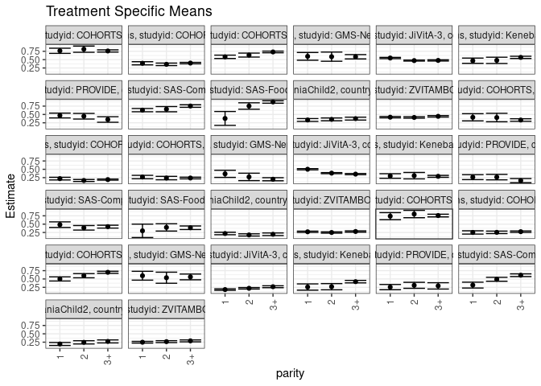

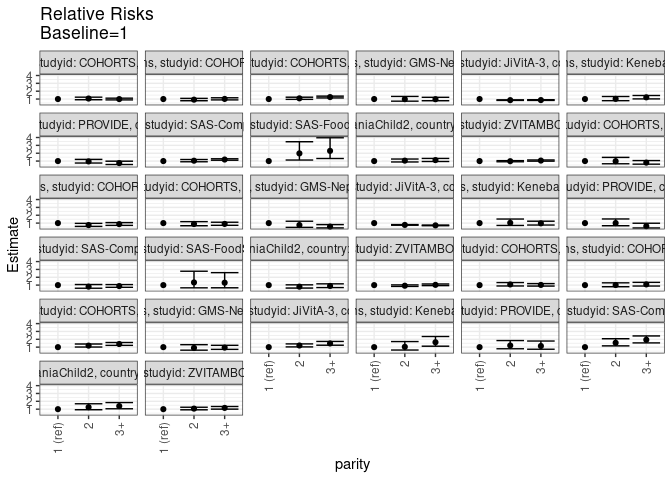

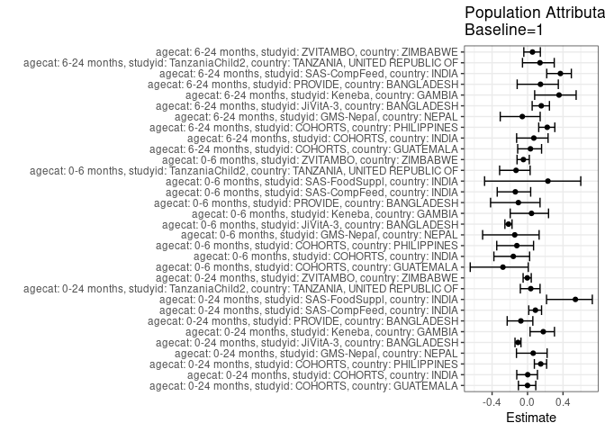

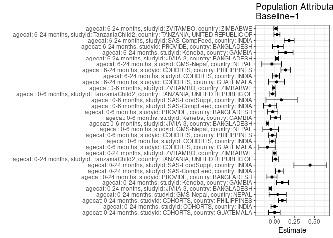

## Results Table

### Parameter: TSM

| agecat | studyid | country | intervention_level | baseline_level | estimate | ci_lower | ci_upper |
| --- | --- | --- | --- | --- | --- | --- | --- |
| 0-24 months | COHORTS | GUATEMALA | 1 | NA | 0.7642912 | 0.6870494 | 0.8415329 |
| 0-24 months | COHORTS | GUATEMALA | 2 | NA | 0.8129997 | 0.7193514 | 0.9066480 |
| 0-24 months | COHORTS | GUATEMALA | 3+ | NA | 0.7592148 | 0.7257242 | 0.7927055 |
| 0-24 months | COHORTS | INDIA | 1 | NA | 0.3904697 | 0.3429812 | 0.4379581 |
| 0-24 months | COHORTS | INDIA | 2 | NA | 0.3597065 | 0.3223743 | 0.3970387 |
| 0-24 months | COHORTS | INDIA | 3+ | NA | 0.3964367 | 0.3749036 | 0.4179699 |
| 0-24 months | COHORTS | PHILIPPINES | 1 | NA | 0.5842270 | 0.5338542 | 0.6345998 |
| 0-24 months | COHORTS | PHILIPPINES | 2 | NA | 0.6360323 | 0.5770183 | 0.6950463 |
| 0-24 months | COHORTS | PHILIPPINES | 3+ | NA | 0.7302795 | 0.7053814 | 0.7551776 |
| 0-24 months | GMS-Nepal | NEPAL | 1 | NA | 0.5983973 | 0.4827510 | 0.7140436 |
| 0-24 months | GMS-Nepal | NEPAL | 2 | NA | 0.5883954 | 0.4508629 | 0.7259279 |
| 0-24 months | GMS-Nepal | NEPAL | 3+ | NA | 0.5859827 | 0.5211508 | 0.6508146 |
| 0-24 months | JiVitA-3 | BANGLADESH | 1 | NA | 0.5484890 | 0.5302451 | 0.5667329 |
| 0-24 months | JiVitA-3 | BANGLADESH | 2 | NA | 0.4713369 | 0.4556400 | 0.4870339 |
| 0-24 months | JiVitA-3 | BANGLADESH | 3+ | NA | 0.4761417 | 0.4581494 | 0.4941341 |
| 0-24 months | Keneba | GAMBIA | 1 | NA | 0.4666973 | 0.3877731 | 0.5456216 |
| 0-24 months | Keneba | GAMBIA | 2 | NA | 0.4778322 | 0.3839796 | 0.5716848 |
| 0-24 months | Keneba | GAMBIA | 3+ | NA | 0.5674050 | 0.5341156 | 0.6006944 |
| 0-24 months | PROVIDE | BANGLADESH | 1 | NA | 0.4685669 | 0.3965944 | 0.5405395 |
| 0-24 months | PROVIDE | BANGLADESH | 2 | NA | 0.4469976 | 0.3627771 | 0.5312181 |
| 0-24 months | PROVIDE | BANGLADESH | 3+ | NA | 0.3488834 | 0.2661278 | 0.4316390 |
| 0-24 months | SAS-CompFeed | INDIA | 1 | NA | 0.6301491 | 0.5810218 | 0.6792764 |
| 0-24 months | SAS-CompFeed | INDIA | 2 | NA | 0.6588958 | 0.5803584 | 0.7374332 |
| 0-24 months | SAS-CompFeed | INDIA | 3+ | NA | 0.7529745 | 0.7149185 | 0.7910304 |
| 0-24 months | SAS-FoodSuppl | INDIA | 1 | NA | 0.3809524 | 0.1730038 | 0.5889009 |
| 0-24 months | SAS-FoodSuppl | INDIA | 2 | NA | 0.7532468 | 0.6568366 | 0.8496569 |
| 0-24 months | SAS-FoodSuppl | INDIA | 3+ | NA | 0.8750000 | 0.8387213 | 0.9112787 |
| 0-24 months | TanzaniaChild2 | TANZANIA, UNITED REPUBLIC OF | 1 | NA | 0.3344483 | 0.2917876 | 0.3771089 |
| 0-24 months | TanzaniaChild2 | TANZANIA, UNITED REPUBLIC OF | 2 | NA | 0.3530394 | 0.3106384 | 0.3954404 |
| 0-24 months | TanzaniaChild2 | TANZANIA, UNITED REPUBLIC OF | 3+ | NA | 0.3756152 | 0.3319284 | 0.4193020 |

[output cut: 66 more lines]

### Parameter: E(Y)

| agecat | studyid | country | intervention_level | baseline_level | estimate | ci_lower | ci_upper |
| --- | --- | --- | --- | --- | --- | --- | --- |
| 0-24 months | COHORTS | GUATEMALA | NA | NA | 0.7639706 | 0.7413939 | 0.7865473 |
| 0-24 months | COHORTS | INDIA | NA | NA | 0.3911447 | 0.3770865 | 0.4052029 |
| 0-24 months | COHORTS | PHILIPPINES | NA | NA | 0.6863963 | 0.6699497 | 0.7028430 |
| 0-24 months | GMS-Nepal | NEPAL | NA | NA | 0.6389685 | 0.6033115 | 0.6746254 |
| 0-24 months | JiVitA-3 | BANGLADESH | NA | NA | 0.4953171 | 0.4874955 | 0.5031388 |
| 0-24 months | Keneba | GAMBIA | NA | NA | 0.5673367 | 0.5455633 | 0.5891101 |
| 0-24 months | PROVIDE | BANGLADESH | NA | NA | 0.4357143 | 0.3989556 | 0.4724730 |
| 0-24 months | SAS-CompFeed | INDIA | NA | NA | 0.6914547 | 0.6510509 | 0.7318584 |
| 0-24 months | SAS-FoodSuppl | INDIA | NA | NA | 0.8277512 | 0.7915095 | 0.8639929 |
| 0-24 months | TanzaniaChild2 | TANZANIA, UNITED REPUBLIC OF | NA | NA | 0.3470513 | 0.3278294 | 0.3662733 |
| 0-24 months | ZVITAMBO | ZIMBABWE | NA | NA | 0.4171108 | 0.4089639 | 0.4252576 |
| 0-6 months | COHORTS | GUATEMALA | NA | NA | 0.3253896 | 0.2975756 | 0.3532035 |
| 0-6 months | COHORTS | INDIA | NA | NA | 0.1902526 | 0.1787489 | 0.2017563 |
| 0-6 months | COHORTS | PHILIPPINES | NA | NA | 0.2390451 | 0.2239262 | 0.2541640 |
| 0-6 months | GMS-Nepal | NEPAL | NA | NA | 0.3180516 | 0.2834770 | 0.3526261 |
| 0-6 months | JiVitA-3 | BANGLADESH | NA | NA | 0.4129818 | 0.4055453 | 0.4204184 |
| 0-6 months | Keneba | GAMBIA | NA | NA | 0.3135456 | 0.2924164 | 0.3346748 |
| 0-6 months | PROVIDE | BANGLADESH | NA | NA | 0.2400000 | 0.2083392 | 0.2716608 |
| 0-6 months | SAS-CompFeed | INDIA | NA | NA | 0.4254902 | 0.3977202 | 0.4532601 |
| 0-6 months | SAS-FoodSuppl | INDIA | NA | NA | 0.3894231 | 0.3425088 | 0.4363374 |
| 0-6 months | TanzaniaChild2 | TANZANIA, UNITED REPUBLIC OF | NA | NA | 0.1947391 | 0.1787488 | 0.2107293 |
| 0-6 months | ZVITAMBO | ZIMBABWE | NA | NA | 0.2586796 | 0.2514399 | 0.2659192 |
| 6-24 months | COHORTS | GUATEMALA | NA | NA | 0.7642458 | 0.7364214 | 0.7920702 |
| 6-24 months | COHORTS | INDIA | NA | NA | 0.2705750 | 0.2559548 | 0.2851951 |
| 6-24 months | COHORTS | PHILIPPINES | NA | NA | 0.6449788 | 0.6246093 | 0.6653483 |
| 6-24 months | GMS-Nepal | NEPAL | NA | NA | 0.5642317 | 0.5153938 | 0.6130696 |
| 6-24 months | JiVitA-3 | BANGLADESH | NA | NA | 0.2162394 | 0.2068628 | 0.2256160 |
| 6-24 months | Keneba | GAMBIA | NA | NA | 0.4014652 | 0.3754511 | 0.4274793 |
| 6-24 months | PROVIDE | BANGLADESH | NA | NA | 0.3004386 | 0.2583143 | 0.3425629 |
| 6-24 months | SAS-CompFeed | INDIA | NA | NA | 0.5030750 | 0.4588491 | 0.5473009 |
| 6-24 months | TanzaniaChild2 | TANZANIA, UNITED REPUBLIC OF | NA | NA | 0.2276474 | 0.2069456 | 0.2483493 |
| 6-24 months | ZVITAMBO | ZIMBABWE | NA | NA | 0.2629473 | 0.2535857 | 0.2723089 |

### Parameter: RR

| agecat | studyid | country | intervention_level | baseline_level | estimate | ci_lower | ci_upper |
| --- | --- | --- | --- | --- | --- | --- | --- |
| 0-24 months | COHORTS | GUATEMALA | 1 | 1 | 1.0000000 | 1.0000000 | 1.0000000 |
| 0-24 months | COHORTS | GUATEMALA | 2 | 1 | 1.0637304 | 0.9127986 | 1.2396188 |
| 0-24 months | COHORTS | GUATEMALA | 3+ | 1 | 0.9933581 | 0.8899173 | 1.1088225 |
| 0-24 months | COHORTS | INDIA | 1 | 1 | 1.0000000 | 1.0000000 | 1.0000000 |
| 0-24 months | COHORTS | INDIA | 2 | 1 | 0.9212150 | 0.7856571 | 1.0801621 |
| 0-24 months | COHORTS | INDIA | 3+ | 1 | 1.0152817 | 0.8893000 | 1.1591105 |
| 0-24 months | COHORTS | PHILIPPINES | 1 | 1 | 1.0000000 | 1.0000000 | 1.0000000 |
| 0-24 months | COHORTS | PHILIPPINES | 2 | 1 | 1.0886733 | 0.9598951 | 1.2347282 |
| 0-24 months | COHORTS | PHILIPPINES | 3+ | 1 | 1.2499928 | 1.1400680 | 1.3705164 |
| 0-24 months | GMS-Nepal | NEPAL | 1 | 1 | 1.0000000 | 1.0000000 | 1.0000000 |
| 0-24 months | GMS-Nepal | NEPAL | 2 | 1 | 0.9832854 | 0.7264607 | 1.3309050 |
| 0-24 months | GMS-Nepal | NEPAL | 3+ | 1 | 0.9792535 | 0.7836538 | 1.2236748 |
| 0-24 months | JiVitA-3 | BANGLADESH | 1 | 1 | 1.0000000 | 1.0000000 | 1.0000000 |
| 0-24 months | JiVitA-3 | BANGLADESH | 2 | 1 | 0.8593371 | 0.8217674 | 0.8986244 |
| 0-24 months | JiVitA-3 | BANGLADESH | 3+ | 1 | 0.8680972 | 0.8271230 | 0.9111011 |
| 0-24 months | Keneba | GAMBIA | 1 | 1 | 1.0000000 | 1.0000000 | 1.0000000 |
| 0-24 months | Keneba | GAMBIA | 2 | 1 | 1.0238589 | 0.7903008 | 1.3264406 |
| 0-24 months | Keneba | GAMBIA | 3+ | 1 | 1.2157880 | 1.0167425 | 1.4538002 |
| 0-24 months | PROVIDE | BANGLADESH | 1 | 1 | 1.0000000 | 1.0000000 | 1.0000000 |
| 0-24 months | PROVIDE | BANGLADESH | 2 | 1 | 0.9539674 | 0.7502954 | 1.2129273 |
| 0-24 months | PROVIDE | BANGLADESH | 3+ | 1 | 0.7445754 | 0.5633071 | 0.9841746 |
| 0-24 months | SAS-CompFeed | INDIA | 1 | 1 | 1.0000000 | 1.0000000 | 1.0000000 |
| 0-24 months | SAS-CompFeed | INDIA | 2 | 1 | 1.0456189 | 0.9109091 | 1.2002502 |
| 0-24 months | SAS-CompFeed | INDIA | 3+ | 1 | 1.1949148 | 1.1082086 | 1.2884048 |
| 0-24 months | SAS-FoodSuppl | INDIA | 1 | 1 | 1.0000000 | 1.0000000 | 1.0000000 |
| 0-24 months | SAS-FoodSuppl | INDIA | 2 | 1 | 1.9772727 | 1.1286797 | 3.4638767 |
| 0-24 months | SAS-FoodSuppl | INDIA | 3+ | 1 | 2.2968750 | 1.3285819 | 3.9708764 |
| 0-24 months | TanzaniaChild2 | TANZANIA, UNITED REPUBLIC OF | 1 | 1 | 1.0000000 | 1.0000000 | 1.0000000 |
| 0-24 months | TanzaniaChild2 | TANZANIA, UNITED REPUBLIC OF | 2 | 1 | 1.0555875 | 0.8864616 | 1.2569806 |
| 0-24 months | TanzaniaChild2 | TANZANIA, UNITED REPUBLIC OF | 3+ | 1 | 1.1230891 | 0.9453840 | 1.3341977 |

[output cut: 66 more lines]

### Parameter: PAR

| agecat | studyid | country | intervention_level | baseline_level | estimate | ci_lower | ci_upper |
| --- | --- | --- | --- | --- | --- | --- | --- |
| 0-24 months | COHORTS | GUATEMALA | 1 | NA | -0.0003206 | -0.0749781 | 0.0743369 |
| 0-24 months | COHORTS | INDIA | 1 | NA | 0.0006750 | -0.0448412 | 0.0461912 |
| 0-24 months | COHORTS | PHILIPPINES | 1 | NA | 0.1021694 | 0.0547804 | 0.1495583 |
| 0-24 months | GMS-Nepal | NEPAL | 1 | NA | 0.0405711 | -0.0691556 | 0.1502979 |
| 0-24 months | JiVitA-3 | BANGLADESH | 1 | NA | -0.0531718 | -0.0697867 | -0.0365570 |
| 0-24 months | Keneba | GAMBIA | 1 | NA | 0.1006393 | 0.0227332 | 0.1785455 |
| 0-24 months | PROVIDE | BANGLADESH | 1 | NA | -0.0328527 | -0.0955734 | 0.0298680 |
| 0-24 months | SAS-CompFeed | INDIA | 1 | NA | 0.0613056 | 0.0100127 | 0.1125985 |
| 0-24 months | SAS-FoodSuppl | INDIA | 1 | NA | 0.4467988 | 0.2462717 | 0.6473259 |
| 0-24 months | TanzaniaChild2 | TANZANIA, UNITED REPUBLIC OF | 1 | NA | 0.0126031 | -0.0258831 | 0.0510892 |
| 0-24 months | ZVITAMBO | ZIMBABWE | 1 | NA | -0.0012934 | -0.0204158 | 0.0178290 |
| 0-6 months | COHORTS | GUATEMALA | 1 | NA | -0.0903628 | -0.1953427 | 0.0146172 |
| 0-6 months | COHORTS | INDIA | 1 | NA | -0.0305853 | -0.0686954 | 0.0075248 |
| 0-6 months | COHORTS | PHILIPPINES | 1 | NA | -0.0288762 | -0.0781632 | 0.0204108 |
| 0-6 months | GMS-Nepal | NEPAL | 1 | NA | -0.0460162 | -0.1460848 | 0.0540524 |
| 0-6 months | JiVitA-3 | BANGLADESH | 1 | NA | -0.0886133 | -0.1050982 | -0.0721285 |
| 0-6 months | Keneba | GAMBIA | 1 | NA | 0.0140279 | -0.0532797 | 0.0813356 |
| 0-6 months | PROVIDE | BANGLADESH | 1 | NA | -0.0248144 | -0.0910760 | 0.0414473 |
| 0-6 months | SAS-CompFeed | INDIA | 1 | NA | -0.0586927 | -0.1384104 | 0.0210250 |
| 0-6 months | SAS-FoodSuppl | INDIA | 1 | NA | 0.0894231 | -0.1074162 | 0.2862624 |
| 0-6 months | TanzaniaChild2 | TANZANIA, UNITED REPUBLIC OF | 1 | NA | -0.0253094 | -0.0586621 | 0.0080433 |
| 0-6 months | ZVITAMBO | ZIMBABWE | 1 | NA | -0.0121550 | -0.0300230 | 0.0057130 |
| 6-24 months | COHORTS | GUATEMALA | 1 | NA | 0.0250517 | -0.0776131 | 0.1277166 |
| 6-24 months | COHORTS | INDIA | 1 | NA | 0.0191565 | -0.0285458 | 0.0668588 |
| 6-24 months | COHORTS | PHILIPPINES | 1 | NA | 0.1432210 | 0.0850020 | 0.2014401 |
| 6-24 months | GMS-Nepal | NEPAL | 1 | NA | -0.0334246 | -0.1593870 | 0.0925377 |
| 6-24 months | JiVitA-3 | BANGLADESH | 1 | NA | 0.0335258 | 0.0123182 | 0.0547334 |
| 6-24 months | Keneba | GAMBIA | 1 | NA | 0.1425927 | 0.0501073 | 0.2350781 |
| 6-24 months | PROVIDE | BANGLADESH | 1 | NA | 0.0438392 | -0.0252180 | 0.1128964 |
| 6-24 months | SAS-CompFeed | INDIA | 1 | NA | 0.1863274 | 0.1246047 | 0.2480501 |
| 6-24 months | TanzaniaChild2 | TANZANIA, UNITED REPUBLIC OF | 1 | NA | 0.0319669 | -0.0086088 | 0.0725427 |
| 6-24 months | ZVITAMBO | ZIMBABWE | 1 | NA | 0.0146318 | -0.0098466 | 0.0391101 |

### Parameter: PAF

| agecat | studyid | country | intervention_level | baseline_level | estimate | ci_lower | ci_upper |
| --- | --- | --- | --- | --- | --- | --- | --- |
| 0-24 months | COHORTS | GUATEMALA | 1 | NA | -0.0004196 | -0.1030753 | 0.0926826 |
| 0-24 months | COHORTS | INDIA | 1 | NA | 0.0017258 | -0.1216938 | 0.1115655 |
| 0-24 months | COHORTS | PHILIPPINES | 1 | NA | 0.1488489 | 0.0767790 | 0.2152928 |
| 0-24 months | GMS-Nepal | NEPAL | 1 | NA | 0.0634948 | -0.1250606 | 0.2204490 |
| 0-24 months | JiVitA-3 | BANGLADESH | 1 | NA | -0.1073491 | -0.1414797 | -0.0742390 |
| 0-24 months | Keneba | GAMBIA | 1 | NA | 0.1773891 | 0.0284903 | 0.3034669 |
| 0-24 months | PROVIDE | BANGLADESH | 1 | NA | -0.0753995 | -0.2297536 | 0.0595806 |
| 0-24 months | SAS-CompFeed | INDIA | 1 | NA | 0.0886618 | 0.0137214 | 0.1579079 |
| 0-24 months | SAS-FoodSuppl | INDIA | 1 | NA | 0.5397743 | 0.2142753 | 0.7304301 |
| 0-24 months | TanzaniaChild2 | TANZANIA, UNITED REPUBLIC OF | 1 | NA | 0.0363148 | -0.0811860 | 0.1410458 |
| 0-24 months | ZVITAMBO | ZIMBABWE | 1 | NA | -0.0031008 | -0.0500106 | 0.0417133 |
| 0-6 months | COHORTS | GUATEMALA | 1 | NA | -0.2777064 | -0.6464187 | 0.0084335 |
| 0-6 months | COHORTS | INDIA | 1 | NA | -0.1607614 | -0.3795246 | 0.0233107 |
| 0-6 months | COHORTS | PHILIPPINES | 1 | NA | -0.1207982 | -0.3473941 | 0.0676902 |
| 0-6 months | GMS-Nepal | NEPAL | 1 | NA | -0.1446816 | -0.5067766 | 0.1303979 |
| 0-6 months | JiVitA-3 | BANGLADESH | 1 | NA | -0.2145696 | -0.2553573 | -0.1751071 |
| 0-6 months | Keneba | GAMBIA | 1 | NA | 0.0447397 | -0.1955460 | 0.2367318 |
| 0-6 months | PROVIDE | BANGLADESH | 1 | NA | -0.1033931 | -0.4171857 | 0.1409196 |
| 0-6 months | SAS-CompFeed | INDIA | 1 | NA | -0.1379414 | -0.3421500 | 0.0351969 |
| 0-6 months | SAS-FoodSuppl | INDIA | 1 | NA | 0.2296296 | -0.4847259 | 0.6002828 |
| 0-6 months | TanzaniaChild2 | TANZANIA, UNITED REPUBLIC OF | 1 | NA | -0.1299657 | -0.3150025 | 0.0290342 |
| 0-6 months | ZVITAMBO | ZIMBABWE | 1 | NA | -0.0469888 | -0.1184155 | 0.0198763 |
| 6-24 months | COHORTS | GUATEMALA | 1 | NA | 0.0327797 | -0.1113055 | 0.1581836 |
| 6-24 months | COHORTS | INDIA | 1 | NA | 0.0707991 | -0.1232273 | 0.2313094 |
| 6-24 months | COHORTS | PHILIPPINES | 1 | NA | 0.2220554 | 0.1259844 | 0.3075664 |
| 6-24 months | GMS-Nepal | NEPAL | 1 | NA | -0.0592392 | -0.3081277 | 0.1422951 |
| 6-24 months | JiVitA-3 | BANGLADESH | 1 | NA | 0.1550401 | 0.0519347 | 0.2469325 |
| 6-24 months | Keneba | GAMBIA | 1 | NA | 0.3551807 | 0.0801886 | 0.5479596 |
| 6-24 months | PROVIDE | BANGLADESH | 1 | NA | 0.1459174 | -0.1170560 | 0.3469825 |
| 6-24 months | SAS-CompFeed | INDIA | 1 | NA | 0.3703769 | 0.2165570 | 0.4939960 |
| 6-24 months | TanzaniaChild2 | TANZANIA, UNITED REPUBLIC OF | 1 | NA | 0.1404229 | -0.0570497 | 0.3010047 |
| 6-24 months | ZVITAMBO | ZIMBABWE | 1 | NA | 0.0556453 | -0.0421587 | 0.1442706 |